# SyedMuzammilSyedRiyazAhamed_9012161_Lab1

## **Practical Lab 1 - Univariate Linear Regression on the California Housing Prices Dataset**

### Name: Syed Muzammil Syed Riyaz Ahamed

### Student Id: 9012161

### Section: 2

### **Objective:**

##### This goal of the report is to build up and evaluate three different univariate linear regression models that describe the relationship between median house value (a dependent variable) and three independent variables: median income, population, and number of households. The aim is to explain how strong and the nature of the relationship is between median house value and each one of these independent variables taken individually.

### **Importing Python Libraries:**

```python
import pandas as pd
import matplotlib.pyplot as plt
import seaborn as sns
from sklearn import linear_model
from sklearn.metrics import mean_squared_error, mean_absolute_error
```

### **Obtaining the Data:**

##### Source: The data is downloaded from Kaggle and the link is provided below for reference.

[California_Housing_Prices](https://www.kaggle.com/datasets/camnugent/california-housing-prices/data)

##### Code Reference: [GitHub](https://github.com/CSCN8010/CSCN8010/blob/main/class_notebooks/linear_regression/linear_regression_example.ipynb)

```python
housing_data = pd.read_csv('D:\CSCN8010-Labs\housing.csv')
```

### **Exploratory Data Analysis:**

##### The dataset for the housing prices are given below

```python
housing_data.describe()
```

|  | longitude | latitude | housing_median_age | total_rooms | total_bedrooms | population | households | median_income | median_house_value |
| --- | --- | --- | --- | --- | --- | --- | --- | --- | --- |
| count | 20640.000000 | 20640.000000 | 20640.000000 | 20640.000000 | 20433.000000 | 20640.000000 | 20640.000000 | 20640.000000 | 20640.000000 |
| mean | -119.569704 | 35.631861 | 28.639486 | 2635.763081 | 537.870553 | 1425.476744 | 499.539680 | 3.870671 | 206855.816909 |
| std | 2.003532 | 2.135952 | 12.585558 | 2181.615252 | 421.385070 | 1132.462122 | 382.329753 | 1.899822 | 115395.615874 |
| min | -124.350000 | 32.540000 | 1.000000 | 2.000000 | 1.000000 | 3.000000 | 1.000000 | 0.499900 | 14999.000000 |
| 25% | -121.800000 | 33.930000 | 18.000000 | 1447.750000 | 296.000000 | 787.000000 | 280.000000 | 2.563400 | 119600.000000 |
| 50% | -118.490000 | 34.260000 | 29.000000 | 2127.000000 | 435.000000 | 1166.000000 | 409.000000 | 3.534800 | 179700.000000 |
| 75% | -118.010000 | 37.710000 | 37.000000 | 3148.000000 | 647.000000 | 1725.000000 | 605.000000 | 4.743250 | 264725.000000 |
| max | -114.310000 | 41.950000 | 52.000000 | 39320.000000 | 6445.000000 | 35682.000000 | 6082.000000 | 15.000100 | 500001.000000 |

### **Scatter Plot:**

### Median House Value vs Median Income:

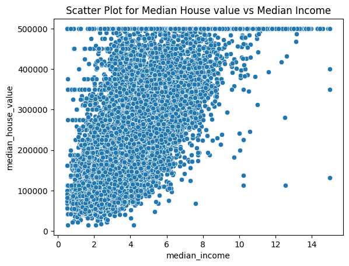

```python
class MedianIncome:

    def medianIncome():
        plt.title('Scatter Plot for Median House value vs Median Income')
        sns.scatterplot(x= 'median_income', y= 'median_house_value', data= housing_data)

income = MedianIncome
income.medianIncome()
```

##### Interpretation: This scatter plot shows that with an increased median income, there is an increased connection with median house value. As the incomes go higher, it would values of the house rise as well. This means higher income ranges could predict higher-priced homes. Notice that the house values do tend to cap around 500,000 dollars, which might represent some sort of upper limit, also notice the greater number of points at lower and middle incomes.

##### Insight for Regression: Since there is a strong positive connection, median income would likely be a highly significant predictor if a linear regression model were fit, and could perhaps explain much of the variation in house values.

### Median House Value vs Population:

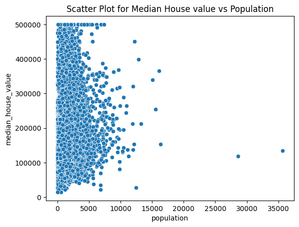

```python
class Population:

    def population():
        plt.title('Scatter Plot for Median House value vs Population')
        sns.scatterplot(x= 'population', y= 'median_house_value', data= housing_data)

population = Population
population.population()
```

##### Interpretation: The above scatter plot does not show any strong linear relationship between the population size and house value. Even though most of the data points are concentrated at lower numbers of population (0-10,000), the house values at this point spread out over a wide range.

##### Insight for Regression: The population is likely to be a simple predictor of the house values in a simple linear model. Yet, it might be worth digging deeper for more fine pattern.

### Median House value vs Number of Households

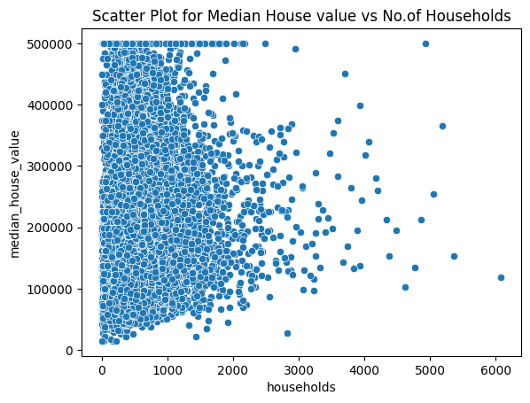

```python
class No_of_Households:

    def households():
        plt.title('Scatter Plot for Median House value vs No.of Households')
        sns.scatterplot(x= 'households', y= 'median_house_value', data= housing_data)

noOfHouseholds = No_of_Households
noOfHouseholds.households()
```

##### Interpretation: There is no distinct linear relationship between median house value and the number of households. Most points tend to cluster at the low end of the household size scale, with house values high but capped at 500,000 as in the previous graph.

##### Insight for Regression: The relationship may point out that the number of households in this case plays a less important role in the determination of house values. Without more context, it probably will not be an ideal contributor to the linear regression model.

### **Observation of 4 variables:**

### 1. Median Housing Value:

##### Meaning: The median value of houses in a specific area.

##### Range: 0 to 500,000.

##### Characteristics: Due to market regulation there is a clear upper limit on house prices.

### 2. Median Income:

##### Meaning: Median income of households in an area.

##### Range: 0 t0 15.

##### Characteristics: There is a positive and strong connection with house values, making it a key predictor for housing prices.

### 3. Population:

##### Meaning: Total population in a specific area.

##### Range: 0 to 35000.

##### Characteristics: There is no strong liner pattern with house prices, most observation cluster at lower population levels.

### 4. Number of Households:

##### Meaning: THe number of households in a specific area.

##### Range: O to 6000.

##### Characteristics: There is no clear relationship with house prices, most of the data is concentrated for smaller household sizes.

### **Data Processing:**

```python
housing_preprocessed = housing_data[housing_data.median_house_value != 500001]
```

##### Lets see the difference between actual housing data and processed housing data using **scatter plots**.

### Processed Median House Values vs Median Income:

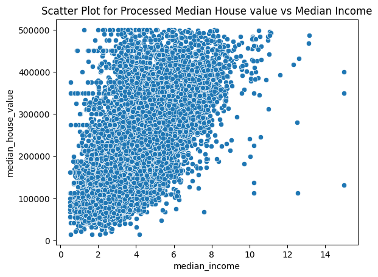

```python
class MedianIncome:

    def medianIncome():
        plt.title('Scatter Plot for Processed Median House value vs Median Income')
        sns.scatterplot(x= 'median_income', y= 'median_house_value', data= housing_preprocessed)

income = MedianIncome
income.medianIncome()
```

### Processed Median House Value vs Population

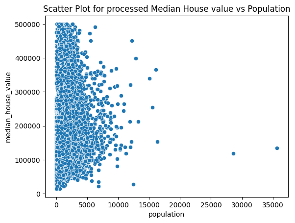

```python
class Population:

    def population():
        plt.title('Scatter Plot for processed Median House value vs Population')
        sns.scatterplot(x= 'population', y= 'median_house_value', data= housing_preprocessed)

population = Population
population.population()
```

### Processed Median House value vs Number of Households:

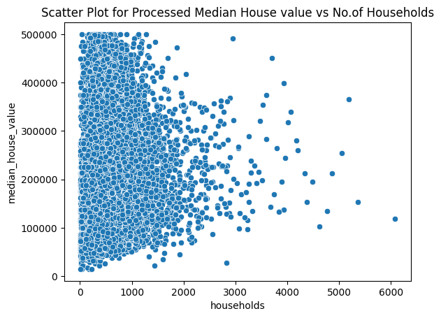

```python
class No_of_Households:

    def households():
        plt.title('Scatter Plot for Processed Median House value vs No.of Households')
        sns.scatterplot(x= 'households', y= 'median_house_value', data= housing_preprocessed)

noOfHouseholds = No_of_Households
noOfHouseholds.households()
```

### Train and Test Split:

##### Splitting the data into training and testing sets.

```python
train_size = int(len(housing_preprocessed) * 0.8)
train = housing_preprocessed[:train_size]
test = housing_preprocessed[train_size:]
```

##### Lets see the training and testing sets in a **scatter plots**.

```python
class TrainTestSets:

    def medianIncome():
        sns.scatterplot(x="median_income", y="median_house_value", data=train, color="blue")
        sns.scatterplot(x="median_income", y="median_house_value", data=test, color="red")

    def population():
        sns.scatterplot(x="population", y="median_house_value", data=train, color="blue")
        sns.scatterplot(x="population", y="median_house_value", data=test, color="red")

    def noOfHouseholds():
        sns.scatterplot(x="households", y="median_house_value", data=train, color="blue")
        sns.scatterplot(x="households", y="median_house_value", data=test, color="red")

trainTestSets = TrainTestSets
```

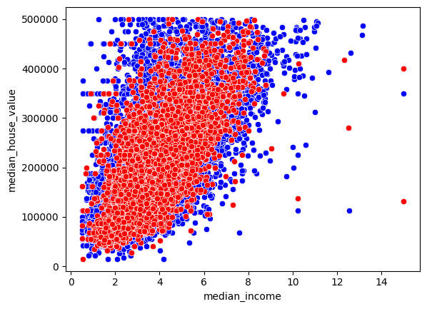

```python
trainTestSets.medianIncome()
```

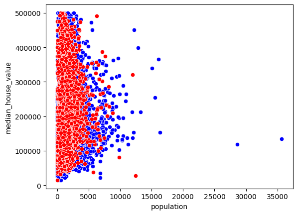

```python
trainTestSets.population()
```

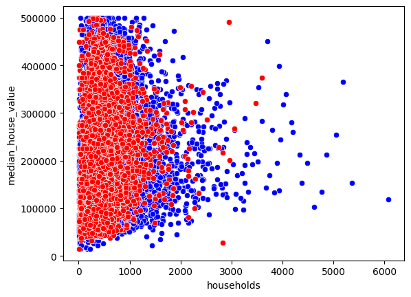

```python
trainTestSets.noOfHouseholds()
```

### **Creation of Liner Regression Models:**

### Median House Value vs Median Income:

```python
# Creating the model
medianIncome_model = linear_model.LinearRegression()

# Training the model
medianIncome_model.fit(X=train[["median_income"]], y=train[["median_house_value"]])
```

```
LinearRegression()
```

```python
# Creating the model
medianIncome_model_test = linear_model.LinearRegression()

# Training the model
medianIncome_model_test.fit(X=test[["median_income"]], y=test[["median_house_value"]])
```

```
LinearRegression()
```

### Median House Value vs Population:

```python
# Creating the model
population_model = linear_model.LinearRegression()

# Training the model
population_model.fit(X=train[["population"]], y=train[["median_house_value"]])
```

```
LinearRegression()
```

```python
# Creating the model
population_model_test = linear_model.LinearRegression()

# Training the model
population_model_test.fit(X=test[["population"]], y=test[["median_house_value"]])
```

```
LinearRegression()
```

### Median House Value vs Number of Households:

```python
# Creating the model
household_model = linear_model.LinearRegression()

# Training the model
household_model.fit(X=train[["households"]], y=train[["median_house_value"]])
```

```
LinearRegression()
```

```python
# Creating the model
household_model_test = linear_model.LinearRegression()

# Training the model
household_model_test.fit(X=test[["households"]], y=test[["median_house_value"]])
```

```
LinearRegression()
```

### **Calculating Intercept, Slope, MSE, MAE:**

##### In the below solution, calculation for **median house value vs median income**, **median house value vs population**, **median house value vs number of households**

```python
class Calculation_TrainData:

    def calculate_trainData():
        result = []

        # Median House Value vs Median Income
        variable_medianIncome = "Median Income"
        intercept_medianIncome = medianIncome_model.intercept_
        slope_medianIncome = medianIncome_model.coef_
        mae_medianIncome = mean_absolute_error(train[['median_house_value']], medianIncome_model.predict(train[['median_income']]))
        mse_medianIncome = mean_squared_error(train[['median_house_value']], medianIncome_model.predict(train[['median_income']]))

        # Median House Value vs Population
        variable_population = "Population"
        intercept_population = population_model.intercept_
        slope_population = population_model.coef_
        mae_population = mean_absolute_error(train[['median_house_value']], population_model.predict(train[['population']]))
        mse_population = mean_squared_error(train[['median_house_value']], population_model.predict(train[['population']]))

        # Median House Value vs Number of Households
        variable_households = "No.of Households"
        intercept_households = household_model.intercept_
        slope_households = household_model.coef_
        mae_households = mean_absolute_error(train[['median_house_value']], household_model.predict(train[['households']]))
        mse_households = mean_squared_error(train[['median_house_value']], household_model.predict(train[['households']]))

        # Result
        result.append([variable_medianIncome, intercept_medianIncome, slope_medianIncome, mae_medianIncome, mse_medianIncome])
        result.append([variable_population, intercept_population, slope_population, mae_population, mse_population])
        result.append([variable_households, intercept_households, slope_households, mae_households, mse_households])
        result_df = pd.DataFrame(result, columns=['Variables', 'Intercept', 'Slope', 'Mean Absolute Value', 'Mean Squared Value'])
        return result_df

    def calculate_testData():
        result = []

        # Median House Value vs Median Income
        variable_medianIncome = "Median Income"
        intercept_medianIncome = medianIncome_model_test.intercept_
        slope_medianIncome = medianIncome_model_test.coef_
        mae_medianIncome = mean_absolute_error(test[['median_house_value']], medianIncome_model_test.predict(test[['median_income']]))
        mse_medianIncome = mean_squared_error(test[['median_house_value']], medianIncome_model_test.predict(test[['median_income']]))

        # Median House Value vs Population
        variable_population = "Population"
        intercept_population = population_model_test.intercept_
        slope_population = population_model_test.coef_
        mae_population = mean_absolute_error(test[['median_house_value']], population_model_test.predict(test[['population']]))
        mse_population = mean_squared_error(test[['median_house_value']], population_model_test.predict(test[['population']]))

        # Median House Value vs Number of Households
        variable_households = "No.of Households"
        intercept_households = household_model_test.intercept_
        slope_households = household_model_test.coef_
        mae_households = mean_absolute_error(test[['median_house_value']], household_model_test.predict(test[['households']]))
        mse_households = mean_squared_error(test[['median_house_value']], household_model_test.predict(test[['households']]))

        # Result
        result.append([variable_medianIncome, intercept_medianIncome, slope_medianIncome, mae_medianIncome, mse_medianIncome])
        result.append([variable_population, intercept_population, slope_population, mae_population, mse_population])
        result.append([variable_households, intercept_households, slope_households, mae_households, mse_households])
        result_df = pd.DataFrame(result, columns=['Variables', 'Intercept', 'Slope', 'Mean Absolute Value', 'Mean Squared Value'])
        return result_df

calculation = Calculation_TrainData
trainData = calculation.calculate_trainData()
testData = calculation.calculate_testData()
print("The calculation for median house value vs other 3 variables for train data are displayed below\n")
print(trainData.to_string(index=False))
print("\nThe calculation for median house value vs other 3 variables for test data are displayed below\n")
print(testData.to_string(index=False))
```

```
The calculation for median house value vs other 3 variables for train data are displayed below

       Variables            Intercept                  Slope  Mean Absolute Value  Mean Squared Value
   Median Income [48204.534368169785]  [[38702.97233842378]]         55839.998641        5.557954e+09
      Population [188081.58862583563] [[0.3286297271249774]]         75879.526606        9.236186e+09
No.of Households [177147.28853834848] [[22.625725908661156]]         75463.106515        9.156895e+09

The calculation for median house value vs other 3 variables for test data are displayed below

       Variables            Intercept                 Slope  Mean Absolute Value  Mean Squared Value
   Median Income  [36201.94497661045] [[44342.79265616039]]         59279.906957        5.655583e+09
      Population  [200432.2955773409] [[5.527816864770166]]         84763.499002        1.045102e+10
No.of Households [191060.56288149784] [[34.99268012800653]]         84132.795338        1.034373e+10
```

### **Scatter Plot with Line Parameter**

### Median House Value vs Median Income

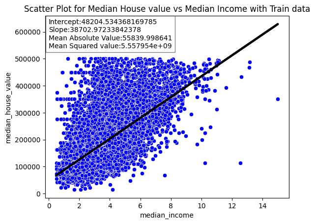

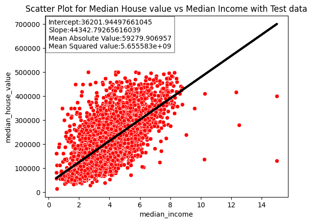

```python
class Plot_MedianIncome:

    def trainData():
        plt.title('Scatter Plot for Median House value vs Median Income with Train data')
        sns.scatterplot(x="median_income", y="median_house_value", data=train, color="blue")
        plt.plot(train[["median_income"]], medianIncome_model.predict(train[["median_income"]]), color="black", linewidth=3)
        plt.text(0, 540000, 'Intercept:48204.534368169785\nSlope:38702.97233842378\nMean Absolute Value:55839.998641\nMean Squared value:5.557954e+09', bbox=dict(facecolor='white', alpha=0.5))
        plt.show()

    def testData():
        plt.title('Scatter Plot for Median House value vs Median Income with Test data')
        sns.scatterplot(x="median_income", y="median_house_value", data=test, color="red")
        plt.plot(test[["median_income"]], medianIncome_model_test.predict(test[["median_income"]]), color="black", linewidth=3)
        plt.text(0, 600000, 'Intercept:36201.94497661045\nSlope:44342.79265616039\nMean Absolute Value:59279.906957\nMean Squared value:5.655583e+09', bbox=dict(facecolor='white', alpha=0.5))
        plt.show()


medianIncomePlot = Plot_MedianIncome
medianIncomePlot.trainData()
medianIncomePlot.testData()
```

### Median House Value vs Population

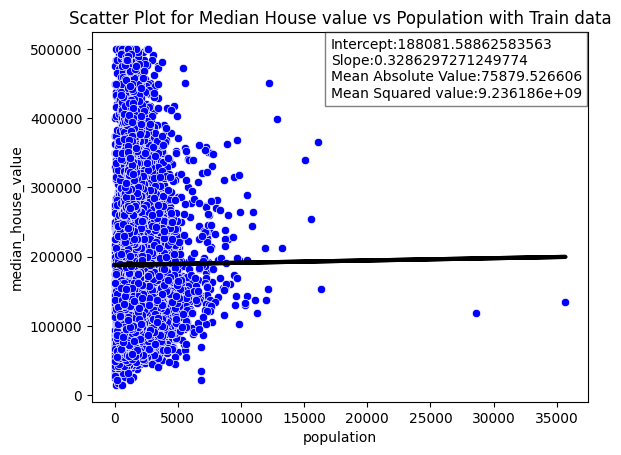

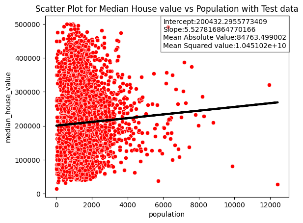

```python
class Plot_Population:

    def trainData():
        plt.title('Scatter Plot for Median House value vs Population with Train data')
        sns.scatterplot(x="population", y="median_house_value", data=train, color="blue")
        plt.plot(train[["population"]], population_model.predict(train[["population"]]), color="black", linewidth=3)
        plt.text(17100, 430000, 'Intercept:188081.58862583563\nSlope:0.3286297271249774\nMean Absolute Value:75879.526606\nMean Squared value:9.236186e+09', bbox=dict(facecolor='white', alpha=0.5))
        plt.show()

    def testData():
        plt.title('Scatter Plot for Median House value vs Population with Test data')
        sns.scatterplot(x="population", y="median_house_value", data=test, color="red")
        plt.plot(test[["population"]], population_model_test.predict(test[["population"]]), color="black", linewidth=3)
        plt.text(6000, 430000, 'Intercept:200432.2955773409\nSlope:5.527816864770166\nMean Absolute Value:84763.499002\nMean Squared value:1.045102e+10', bbox=dict(facecolor='white', alpha=0.5))
        plt.show()


populationPlot = Plot_Population
populationPlot.trainData()
populationPlot.testData()
```

### Median House Value vs Number of Households:

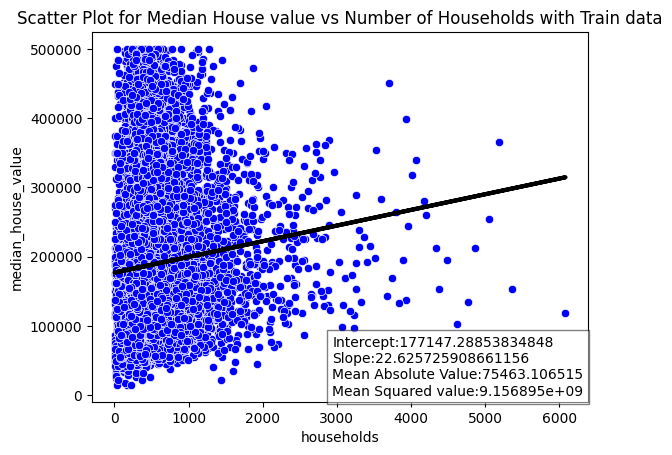

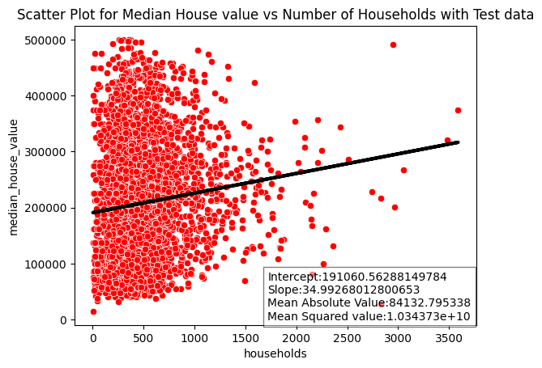

```python
class Plot_Households:

    def trainData():
        plt.title('Scatter Plot for Median House value vs Number of Households with Train data')
        sns.scatterplot(x="households", y="median_house_value", data=train, color="blue")
        plt.plot(train[["households"]], household_model.predict(train[["households"]]), color="black", linewidth=3)
        plt.text(2940, 0, 'Intercept:177147.28853834848\nSlope:22.625725908661156\nMean Absolute Value:75463.106515\nMean Squared value:9.156895e+09', bbox=dict(facecolor='white', alpha=0.5))
        plt.show()

    def testData():
        plt.title('Scatter Plot for Median House value vs Number of Households with Test data')
        sns.scatterplot(x="households", y="median_house_value", data=test, color="red")
        plt.plot(test[["households"]], household_model_test.predict(test[["households"]]), color="black", linewidth=3)
        plt.text(1720, 0, 'Intercept:191060.56288149784\nSlope:34.99268012800653\nMean Absolute Value:84132.795338\nMean Squared value:1.034373e+10', bbox=dict(facecolor='white', alpha=0.5))
        plt.show()


householdsPlot = Plot_Households
householdsPlot.trainData()
householdsPlot.testData()
```

### **Conclusion**

##### The model with **median income** as a variable is the best fitting model as it shows a strong connection with house values and highest slope. Whereas the other 2 models which as **population** and **households** as variables have exhibited a weak relationship with the housing value.

##### Insight: Based on the plots and line parameter above, **median income vs median house values** is the strongest model compared to other to models. This makes the model more reliable for predicting housing prices. The other two models shows minimum influence on the housing prices.